# R Notebook

```r
install.packages('ggplot2')
```

# The data

This data set contains 113,937 loans with 81 variables on each loan, including loan amount, borrower rate (or interest rate), current loan status, borrower income, borrower employment status, borrower credit history, and the latest payment information.

```r
library(ggplot2)
loanData <- read.csv('prosperLoanData.csv')
summary(loanData)
```

```
                   ListingKey     ListingNumber
 17A93590655669644DB4C06:     6   Min.   :      4
 349D3587495831350F0F648:     4   1st Qu.: 400919
 47C1359638497431975670B:     4   Median : 600554
 8474358854651984137201C:     4   Mean   : 627886
 DE8535960513435199406CE:     4   3rd Qu.: 892634
 04C13599434217079754AEE:     3   Max.   :1255725
 (Other)                :113912
                    ListingCreationDate  CreditGrade         Term
 2013-10-02 17:20:16.550000000:     6          :84984   Min.   :12.00
 2013-08-28 20:31:41.107000000:     4   C      : 5649   1st Qu.:36.00
 2013-09-08 09:27:44.853000000:     4   D      : 5153   Median :36.00
 2013-12-06 05:43:13.830000000:     4   B      : 4389   Mean   :40.83
 2013-12-06 11:44:58.283000000:     4   AA     : 3509   3rd Qu.:36.00
 2013-08-21 07:25:22.360000000:     3   HR     : 3508   Max.   :60.00
 (Other)                      :113912   (Other): 6745
                 LoanStatus                  ClosedDate     BorrowerAPR
 Current              :56576                      :58848   Min.   :0.00653
 Completed            :38074   2014-03-04 00:00:00:  105   1st Qu.:0.15629
 Chargedoff           :11992   2014-02-19 00:00:00:  100   Median :0.20976
 Defaulted            : 5018   2014-02-11 00:00:00:   92   Mean   :0.21883
 Past Due (1-15 days) :  806   2012-10-30 00:00:00:   81   3rd Qu.:0.28381
 Past Due (31-60 days):  363   2013-02-26 00:00:00:   78   Max.   :0.51229
 (Other)              : 1108   (Other)            :54633   NA's   :25
  BorrowerRate     LenderYield      EstimatedEffectiveYield EstimatedLoss
 Min.   :0.0000   Min.   :-0.0100   Min.   :-0.183          Min.   :0.005
 1st Qu.:0.1340   1st Qu.: 0.1242   1st Qu.: 0.116          1st Qu.:0.042
 Median :0.1840   Median : 0.1730   Median : 0.162          Median :0.072
 Mean   :0.1928   Mean   : 0.1827   Mean   : 0.169          Mean   :0.080
 3rd Qu.:0.2500   3rd Qu.: 0.2400   3rd Qu.: 0.224          3rd Qu.:0.112
 Max.   :0.4975   Max.   : 0.4925   Max.   : 0.320          Max.   :0.366
                                    NA's   :29084           NA's   :29084
 EstimatedReturn  ProsperRating..numeric. ProsperRating..Alpha.
 Min.   :-0.183   Min.   :1.000                  :29084
 1st Qu.: 0.074   1st Qu.:3.000           C      :18345
 Median : 0.092   Median :4.000           B      :15581
 Mean   : 0.096   Mean   :4.072           A      :14551
 3rd Qu.: 0.117   3rd Qu.:5.000           D      :14274
 Max.   : 0.284   Max.   :7.000           E      : 9795
 NA's   :29084    NA's   :29084           (Other):12307
```

[output cut: 176 more lines]

```
 LP_NonPrincipalRecoverypayments PercentFunded    Recommendations
 Min.   :    0.00                Min.   :0.7000   Min.   : 0.00000
 1st Qu.:    0.00                1st Qu.:1.0000   1st Qu.: 0.00000
 Median :    0.00                Median :1.0000   Median : 0.00000
 Mean   :   25.14                Mean   :0.9986   Mean   : 0.04803
 3rd Qu.:    0.00                3rd Qu.:1.0000   3rd Qu.: 0.00000
 Max.   :21117.90                Max.   :1.0125   Max.   :39.00000

 InvestmentFromFriendsCount InvestmentFromFriendsAmount   Investors
 Min.   : 0.00000           Min.   :    0.00            Min.   :   1.00
 1st Qu.: 0.00000           1st Qu.:    0.00            1st Qu.:   2.00
 Median : 0.00000           Median :    0.00            Median :  44.00
 Mean   : 0.02346           Mean   :   16.55            Mean   :  80.48
 3rd Qu.: 0.00000           3rd Qu.:    0.00            3rd Qu.: 115.00
 Max.   :33.00000           Max.   :25000.00            Max.   :1189.00
```

# First Look

In this data set there are 81 Variables. To Start the most interresting for me seem to be # https://www.prosper.com/Downloads/Services/Documentation/ProsperDataExport_Details.html

What? * LoanOriginalAmount * Term: The length of the loan expressed in months. * Loan Origin Date

Who? * isBorrowerHomeOwner * Occupation * CreditGrade * CurrentDelinquencies

Why? * ListingCategory: numeric ** The category of the listing that the borrower selected when posting their listing: 0 - Not Available, 1 - Debt Consolidation, 2 - Home Improvement, 3 - Business, 4 - Personal Loan, 5 - Student Use, 6 - Auto, 7- Other, 8 - Baby&Adoption, 9 - Boat, 10 - Cosmetic Procedure, 11 - Engagement Ring, 12 - Green Loans, 13 - Household Expenses, 14 - Large Purchases, 15 - Medical/Dental, 16 - Motorcycle, 17 - RV, 18 - Taxes, 19 - Vacation, 20 - Wedding Loans

- BankcardUtilization
- IncomeRange
- EmploymentStatus

Help from Friends? * InvestementFromFriendsAmount * Investors

Is your credit rate ok? *BorrowerAPR: The Borrower’s Annual Percentage Rate (APR) for the loan.* BorrowerRate: The Borrower’s interest rate for this loan. The is the rate the borrower pays if the loan were to close at this point in time. The rate is computed as the LenderRate + GroupLeaderRewardRate (if applicable) + BankDraftFeeAnnualRate (if applicable).

LoanOriginalAmount and Terms by Year - extract the year of the LoanOriginData and save it to a new variable

# How much money is needed?

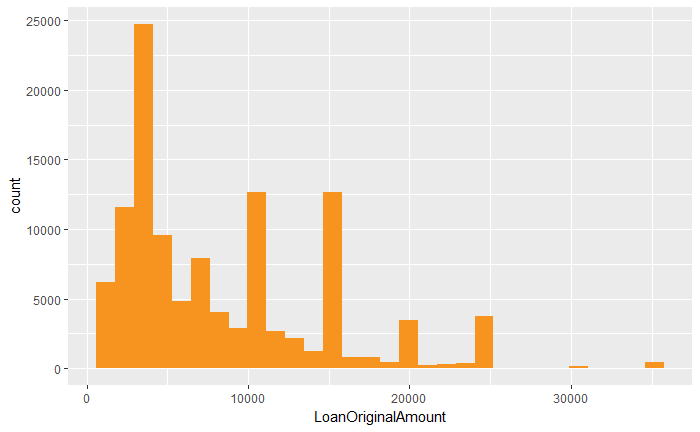

```r
ggplot(aes(x = LoanOriginalAmount), data = loanData) +
  geom_histogram( fill = ('#F79420'))
```

```r
summary(loanData$LoanOriginalAmount)
```

```
   Min. 1st Qu.  Median    Mean 3rd Qu.    Max.
   1000    4000    6500    8337   12000   35000
```

Sehen wir uns nun an, für was das Geld benötigt wurde. -> unsere Annahme bestägigen

```r
# transform the numeric value of categories to readable names:
loanData$Category[loanData$ListingCategory..numeric. == '0'] <- 'Not Availabe'
loanData$Category[loanData$ListingCategory..numeric. == '1'] <- 'Debt Consolidation'
loanData$Category[loanData$ListingCategory..numeric. == '2'] <- 'Home Improvement'
loanData$Category[loanData$ListingCategory..numeric. == '3'] <- 'Business'
loanData$Category[loanData$ListingCategory..numeric. == '4'] <- 'Personal Loan'
loanData$Category[loanData$ListingCategory..numeric. == '5'] <- 'Student Use'
loanData$Category[loanData$ListingCategory..numeric. == '6'] <- 'Auto'
loanData$Category[loanData$ListingCategory..numeric. == '7'] <- 'Other'
loanData$Category[loanData$ListingCategory..numeric. == '8'] <- 'Baby & Adoption'
loanData$Category[loanData$ListingCategory..numeric. == '9'] <- 'Boat'
loanData$Category[loanData$ListingCategory..numeric. == '10'] <- 'Cosmetic Procedure'
loanData$Category[loanData$ListingCategory..numeric. == '11'] <- 'Engagement Ring'
loanData$Category[loanData$ListingCategory..numeric. == '12'] <- 'Green Loans'
loanData$Category[loanData$ListingCategory..numeric. == '13'] <- 'Household Expenses'
loanData$Category[loanData$ListingCategory..numeric. == '14'] <- 'Large Purchases'
loanData$Category[loanData$ListingCategory..numeric. == '15'] <- 'Medical/Dental'
loanData$Category[loanData$ListingCategory..numeric. == '16'] <- 'Motorcycle'
loanData$Category[loanData$ListingCategory..numeric. == '17'] <- 'RV'
loanData$Category[loanData$ListingCategory..numeric. == '18'] <- 'Taxes'
loanData$Category[loanData$ListingCategory..numeric. == '19'] <- 'Vacation'
loanData$Category[loanData$ListingCategory..numeric. == '20'] <- 'Wedding Loans'
```

```r
summary(loanData$Occupation)
```

```
                                                       Accountant/CPA
                              3588                               3233
          Administrative Assistant                            Analyst
                              3688                               3602
                         Architect                           Attorney
                               213                               1046
                         Biologist                         Bus Driver
                               125                                316
                        Car Dealer                            Chemist
                               180                                145
                     Civil Service                             Clergy
                              1457                                196
                          Clerical                Computer Programmer
                              3164                               4478
                      Construction                            Dentist
                              1790                                 68
                            Doctor                Engineer - Chemical
                               494                                225
             Engineer - Electrical              Engineer - Mechanical
                              1125                               1406
                         Executive                            Fireman
                              4311                                422
                  Flight Attendant                       Food Service
                               123                               1123
           Food Service Management                          Homemaker
                              1239                                120
                          Investor                              Judge
                               214                                 22
                           Laborer                        Landscaping
                              1595                                236
                Medical Technician                  Military Enlisted
                              1117                               1272
                  Military Officer                       Nurse's Aide
                               346                                491
                       Nurse (LPN)                         Nurse (RN)
                               492                               2489
                             Other                         Pharmacist
                             28617                                257
        Pilot - Private/Commercial  Police Officer/Correction Officer
                               199                               1578
```

[output cut: 13 more lines]

```
                               741                                 41
Student - College Graduate Student           Student - College Junior
                               245                                112
          Student - College Senior        Student - College Sophomore
                               188                                 69
       Student - Community College         Student - Technical School
                                28                                 16
                           Teacher                     Teacher's Aide
                              3759                                276
             Tradesman - Carpenter            Tradesman - Electrician
                               120                                477
              Tradesman - Mechanic                Tradesman - Plumber
                               951                                102
                      Truck Driver                    Waiter/Waitress
                              1675                                436
```

WHy?

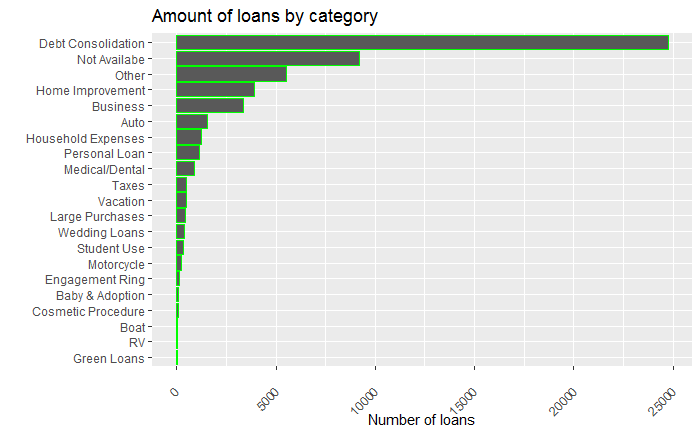

```r
reorder_size <- function(x) {
  factor(x, levels = names(sort(table(x))))
}
ggplot(data= subset(loanData, LoanOriginalAmount > 2500 & LoanOriginalAmount <= 9000), aes(reorder_size(Category))) +
    geom_bar(colour = "green")+
    ggtitle("Amount of loans by category") +
  theme(axis.text.x=element_text(angle=45,hjust=1,vjust=0.5))+
    labs(x="", y = "Number of loans") +
  coord_flip()
```

[output not shown]

[figure not shown]

```r
ggplot(data=loanData, x=Occupation, aes(reorder_size(Occupation))) +
    geom_bar(width= 5, colour = "green", stats="count")+
    ggtitle("Borrowers by Occupation")
```

```r
    labs(x="", y = "Number of loans") +
  coord_flip()
```

[output not shown]

```r
summary(loanData$IsBorrowerHomeowner)
```

```
False  True
56459 57478
```

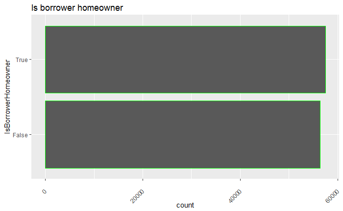

```r
ggplot(data=loanData, aes(IsBorrowerHomeowner)) +
    geom_bar(colour = "green")+
    ggtitle("Is borrower homeowner") +
  theme(axis.text.x=element_text(angle=45,hjust=1,vjust=0.5))+
  coord_flip()
```

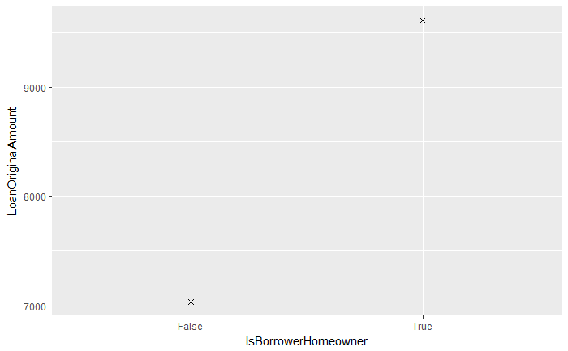

```r
ggplot(aes(x = IsBorrowerHomeowner, y = LoanOriginalAmount),
      data = loanData) +
      stat_summary(fun.y = mean, geom= 'point', shape = 4)
```

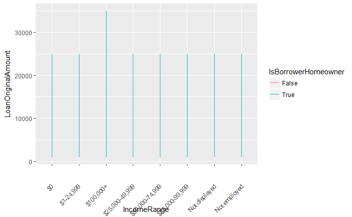

```r
ggplot(aes(x=IncomeRange, y = LoanOriginalAmount),
       data = loanData) +
      theme(axis.text.x=element_text(angle=45,hjust=1,vjust=0.5))+
  geom_line(aes(color= IsBorrowerHomeowner))
```

```r
#ggplot(aes(x= IncomeRange, y = LoanOriginalAmount),
#       data = loanData) +
#  geom_line(stat = 'summary')
```

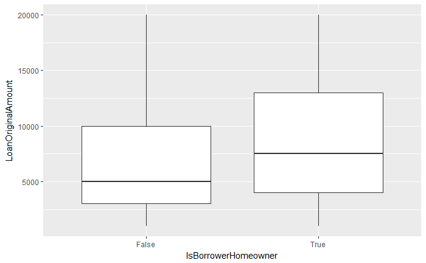

```r
  qplot(x=IsBorrowerHomeowner, y=LoanOriginalAmount,
        data=loanData, geom = 'boxplot') +
  scale_y_continuous(limits = c(1000, 20000))
```